# Assignment1

Daniel ten Wolde

9/22/2019

```r
column_names <- c("region", "date", "variable", "value")
data_county <- read_delim("95274.csv", delim=";")
data_country <- read_delim("95276.csv", delim=";")
names(data_county) <- column_names
names(data_country) <- column_names
```

In above section we read in both input files with a “;” as delimiter. We also correct the column names.

```r
data_county$date <- date_function(data_county$date) # Correct date format for both
data_country$date <- date_function(data_country$date)
data_county$variable <- recode(data_county$variable, "Kapasitetsutnytting av senger (prosent)" =
"Beds percentage capacity utilization", "Kapasitetsutnytting av rom (prosent)" = "Rooms percentage capacity utilization", "Pris per rom (kr)" = "Price per room (kr)") # Translate variables
data_country$variable <- recode(data_country$variable, "Kapasitetsutnytting av senger (prosent)" =
"Beds percentage capacity utilization", "Kapasitetsutnytting av rom (prosent)" = "Rooms percentage capacity utilization", "Pris per rom (kr)" = "Price per room (kr)")
```

In above section of code we correct the date format by replacing the “M” with a “-” and adding days to make the date format work. In addition to that we translate the variables.

```r
all_data <- merge(data_county, data_country, all=TRUE)
country_average_month <- all_data %>% filter(variable == "Price per room (kr)" & region == "0 Hele landet") %>% filter(value != 0)
county_average_month <- all_data %>% filter(variable == "Price per room (kr)" & region != "0 Hele landet") %>% filter(value != 0)

difference_per_month_df <- merge(county_average_month, country_average_month, by="date")
difference_per_month_df$variable.y <- NULL

difference_per_month_df$difference <- c(difference_per_month_df$value.x - difference_per_month_df$value.y)
names(difference_per_month_df) <- c("date", "county", "variable", "county_price", "country", "country_price", "difference")


diff_per_county <- difference_per_month_df %>% group_by(county) %>% summarize(mean(difference))
names(diff_per_county) <- c("county", "mean_diff")
index_min <- which.min(diff_per_county$mean_diff)
index_max <- which.max(diff_per_county$mean_diff)
max_county_per_month <- diff_per_county$county[index_max]
min_county_per_month <- diff_per_county$county[index_min]
```

We created two data frames, one for the entire country and one for all counties with the only variable being Price per room (kr). We then merged the data frames by date so we can get the difference per observation later. We remove a redundant variable. We then calculate the differences and adjust the column names of the data frame for clarity sake. We group by county and calculate the mean of every. We then find the index of the maximum and minimum value to find the county belonging to the maximum and minumum values.

The county that on average per month had the highest positive was 21 Svalbard. The county with the highest negative was 05 Oppland

```r
diff_per_year <- difference_per_month_df
diff_per_year$date <- substring(diff_per_year$date,1,4)
diff_year_county <- diff_per_year %>% group_by(date, county) %>% summarize(mean(difference))
names(diff_year_county) <- c("date", "county", "mean_diff")
index_min <- which.min(diff_year_county$mean_diff)
index_max <- which.max(diff_year_county$mean_diff)
max_county_per_year <- c(diff_year_county$county[index_max], diff_year_county$date[index_max])
min_county_per_year <- c(diff_year_county$county[index_min], diff_year_county$date[index_min])
```

We truncate the date to only remain with the year of the observation. We then group by year and county and calculate the mean of every year of every county. The column names are corrected and we retrieve the indexes for the maximum and minimum values.

The county and year that had the highest positive was 21 Svalbard in the year 2019. The county with the highest negative was 05 Oppland in the year 2008

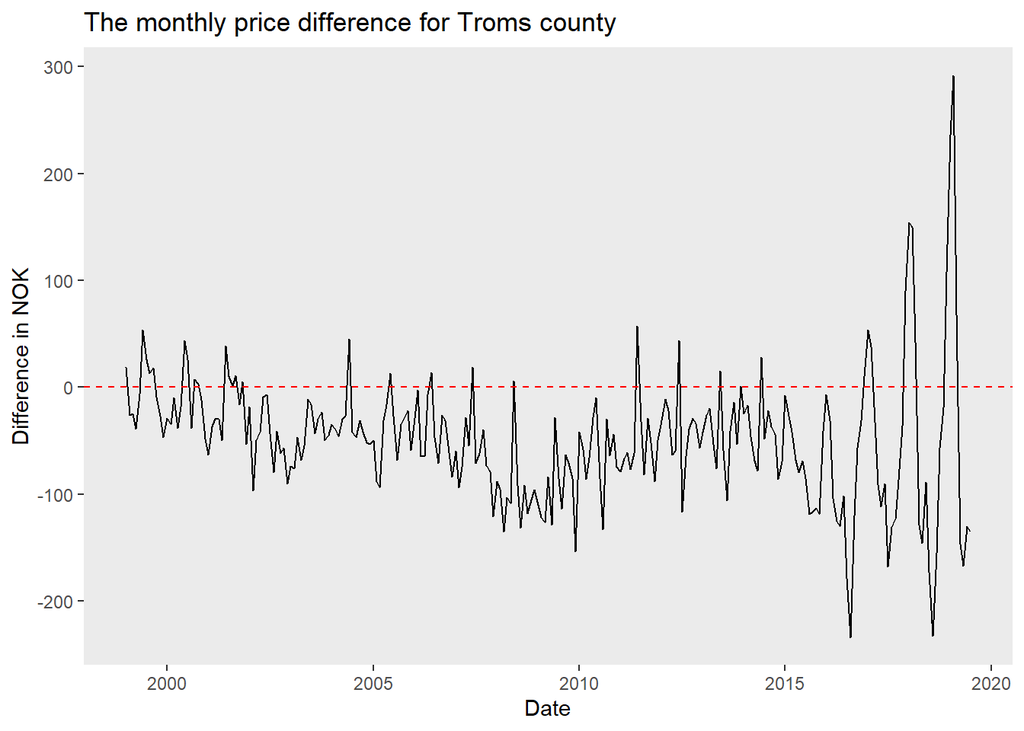

```r
troms_county <- difference_per_month_df %>% filter(county == "19 Troms - Romsa" & date >= as.Date("1999-01-01", origin = 1999-01-01))

ggplot(troms_county, aes(x = date, y = difference)) + geom_line() + ggtitle("The monthly price difference for Troms county ") + labs(y= "Difference in NOK", x = "Date") + geom_hline(yintercept=0, linetype="dashed", color = "red")+ theme(
  panel.border = element_blank(),
  panel.grid.major = element_blank(),
  panel.grid.minor = element_blank(),
  )
```

We filter the data retrieved earlier to only that of the county of Troms from 1999 onwards. We then make a lineplot with the difference on the y-axis and date on the x-axis. We add some styling to make the plot look better.

```r
data_county_after2010 <- data_county %>% filter(date >= as.Date("2010-01-01", origin= 2010-01-01))
room_cap <- data_county_after2010 %>% filter(variable == "Rooms percentage capacity utilization")
price_per_room <- data_county_after2010 %>% filter(variable == "Price per room (kr)")
price_room_cap <- merge(room_cap, price_per_room, by=c("date", "region"))
names(price_room_cap) <- c("date", "region", "room_cap_var", "room_value", "price_var", "price_value")
cor_county_room_price <- price_room_cap %>% group_by(region) %>% summarize(cor(room_value, price_value))
names(cor_county_room_price) = c("region", "correlation_price_room")
print.data.frame(cor_county_room_price)
```

```
##                            region correlation_price_room
## 1                   01 <d8>stfold             0.14500794
## 2                     02 Akershus             0.06021207
## 3                         03 Oslo             0.12934078
## 4                      04 Hedmark             0.06703690
## 5                      05 Oppland             0.22003834
## 6                     06 Buskerud             0.04545407
## 7                     07 Vestfold             0.04869988
## 8                     08 Telemark             0.05799365
## 9                   09 Aust-Agder             0.32471679
## 10                  10 Vest-Agder             0.24628260
## 11                    11 Rogaland             0.21767419
## 12                   12 Hordaland             0.36629115
## 13            14 Sogn og Fjordane             0.16064435
## 14          15 M<f8>re og Romsdal             0.48890380
## 15 16 S<f8>r-Tr<f8>ndelag (-2017)             0.59116312
## 16   17 Nord-Tr<f8>ndelag (-2017)             0.56042379
## 17                    18 Nordland             0.23307838
## 18               19 Troms - Romsa             0.33900311
## 19     20 Finnmark - Finnm<e1>rku             0.14655290
## 20                    21 Svalbard             0.87787708
## 21                50 Tr<f8>ndelag             0.90715650
```

We first filter the data from 2010 onwards. We then split the data in two data frames and merge those together by date and region. Then we calculate any correlation between the room capacity utilization and the price. As can be seen, there is a great spread of correlation as some counties, like Svalbard have a strong correlation, while other counties like Akershus do not show any correlation.